# Solutions to Week 3 In-class Problems

Hyeonsu Kang & Tim Dennis

January 22, 2016

```r
library(ggplot2)
library(dplyr)
library(tidyr)
library(ggvis)
```

## 1.1 Data management with dplyr

### 1. Read in the data

```r
gapminder <- read.csv("https://goo.gl/BtBnPg", header = T, stringsAsFactors = F)
```

### 2. What is the (absolute) difference between the average GDP per capita of Americas and Asia in year 2002?

```r
gdp_bycontinents_byyear <- gapminder %>%
  group_by(continent,year) %>%
  summarize(mean_gdpPercap=mean(gdpPercap))
```

```r
yr2002GdpPercapConti <- gdp_bycontinents_byyear %>%
  filter(year==2002)
yr2002AsiaGdpPercap <- yr2002GdpPercapConti %>%
  filter(continent=="Asia")
yr2002AmericasGdpPercap <- yr2002GdpPercapConti %>%
  filter(continent=="Americas")
abs(yr2002AsiaGdpPercap$mean_gdpPercap - yr2002AmericasGdpPercap$mean_gdpPercap)
```

```
## [1] 886.4133
```

- Another approach to do above, but using `dplyr` for all but the final step.

```r
gdp_byasiaamer_byyear <- gapminder %>%
  group_by(continent,year) %>%
  filter(continent=="Asia" | continent == "Americas", year == "2002") %>%
  summarize(mean_gdpPercap=mean(gdpPercap))

abs(diff(gdp_byasiaamer_byyear$mean_gdpPercap))
```

```
## [1] 886.4133
```

### 3. Which continent had the highest GDP per capita in year 2002?

```r
yr2002ContiGdpPercap <- gdp_bycontinents_byyear %>%
  filter(year==2002)
```

```r
yr2002ContiGdpPercap$continent[which.max(yr2002ContiGdpPercap$mean_gdpPercap)]
```

```
## [1] "Oceania"
```

- Another approach without the intermediary subsetted data frames.
- When trying to create a ranking, you can use dplyr’s `arrange` function, but it will behave oddly on grouped data. We need to ungroup to get arrange to work right. Try commenting the `ungroup()` line to see how it changes.
- We use `top_n()` to return top row, so we get a 1 row ordered data frame
- Can do `which.max()` outside of `%>>%` stanza

```r
g2 <- gapminder %>%
  group_by(continent,year) %>%
  filter(year==2002) %>%
  summarize(mean_gdpPercap=mean(gdpPercap)) %>%
  ungroup() %>%
  arrange(desc(mean_gdpPercap)) %>% #orders the data frame in descending order using arrange & desc
  top_n(1)
head(g2) #top_n grabs the top n rows.
```

```
## Source: local data frame [1 x 3]
##
##   continent  year mean_gdpPercap
##       (chr) (int)          (dbl)
## 1   Oceania  2002       26938.78
```

```r
g2$continent[which.max(g2$mean_gdpPercap)] #we can pull out the which.min as well
```

```
## [1] "Oceania"
```

```r
#g2$continent[which.min(g2$mean_gdpPercap)] #this would work if we hadn't used the top_n() function
```

### 4. Which continent had the lowest GDP per capita in year 2002?

```r
yr2002ContiGdpPercap$continent[which.min(yr2002ContiGdpPercap$mean_gdpPercap)]
```

```
## [1] "Africa"
```

### 5. Which country had the highest GDP per capita in year 1967?

```r
gdp_bycountries_byyear <- gapminder %>%
  group_by(country, year) %>%
  summarize(gdpPercap)
```

```r
yr1967CountGdpPercap <- gdp_bycountries_byyear %>%
  filter(year==1967)

yr1967CountGdpPercap$country[which.max(yr1967CountGdpPercap$gdpPercap)]
```

```
## [1] "Kuwait"
```

```r
yr1967CountGdpPercap$gdpPercap[which.max(yr1967CountGdpPercap$gdpPercap)]
```

```
## [1] 80894.88
```

- Another example of going from gapminder (not saving as a new data frame) to the subsetted data frame to the one row contaning the answer. You could save this as a df and then access use `my_dataframe[1,1]` to get the answer.

```r
gapminder %>%
  group_by(country, year) %>%
  summarize(gdpPercap) %>%
  filter(year == 1967) %>%
  ungroup() %>%
  slice(which.max(gdpPercap))
```

```
## Source: local data frame [1 x 3]
##
##   country  year gdpPercap
##     (chr) (int)     (dbl)
## 1  Kuwait  1967  80894.88
```

### 6. Which country had the highest life expectancy in year 2002 and what was the value of it?

```r
lifeExp_bycountries_byyear <- gapminder %>%
  group_by(country, year) %>%
  summarize(lifeExp)
```

```r
yr2002CountLifeExp <- lifeExp_bycountries_byyear %>%
  filter(year==2002)
```

- the name of the country

```r
yr2002CountLifeExp$country[which.max(yr2002CountLifeExp$lifeExp)]
```

```
## [1] "Japan"
```

- the value of the life expectancy

```r
yr2002CountLifeExp$lifeExp[which.max(yr2002CountLifeExp$lifeExp)]
```

```
## [1] 82
```

### 7. What does the distribution of the log of GDP per capita look like in year 1967?

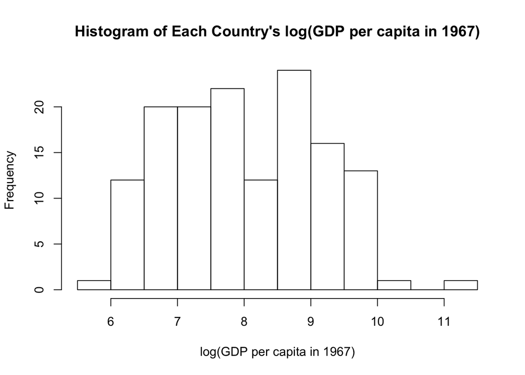

```r
hist(log(yr1967CountGdpPercap$gdpPercap), plot=T, main="Histogram of Each Country's log(GDP per capita in 1967)", xlab="log(GDP per capita in 1967)")
```

### 8. What does the distribution of the life expectancy in year 2002 look like?

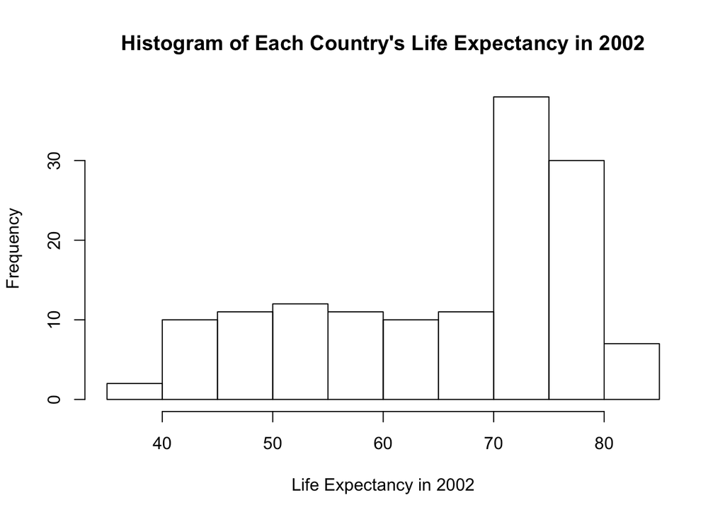

```r
hist(yr2002CountLifeExp$lifeExp, plot=T, main="Histogram of Each Country's Life Expectancy in 2002", xlab="Life Expectancy in 2002")
```

- another way using a viz package that works with %>%

```r
lifeExp_bycountries_byyear %>%
  filter(year==2002) %>%
  ggvis(~lifeExp) %>%
  layer_histograms()
```

```
## Guessing width = 2 # range / 22
```

### 9. Add a log(GDP per capita in 1967) column to the data frame that contains GDP per capita by countries in 1967.

```r
yr1967CountGdpPercapLog <- yr1967CountGdpPercap %>%
  mutate(logGDP=log(gdpPercap))

head(yr1967CountGdpPercapLog)
```

```
## Source: local data frame [6 x 4]
## Groups: country [6]
##
##       country  year  gdpPercap   logGDP
##         (chr) (int)      (dbl)    (dbl)
## 1 Afghanistan  1967   836.1971 6.728864
## 2     Albania  1967  2760.1969 7.923057
## 3     Algeria  1967  3246.9918 8.085484
## 4      Angola  1967  5522.7764 8.616636
## 5   Argentina  1967  8052.9530 8.993794
## 6   Australia  1967 14526.1246 9.583704
```

### 10. Graph (scatter plot) x:Log(GDP per capita in 1967), y:Life Expectancy in 2002

```r
yr1967GDPyr2002LifeExp <- merge(yr1967CountGdpPercapLog, yr2002CountLifeExp, by.x="country", by.y="country")
head(yr1967GDPyr2002LifeExp)
```

```
##       country year.x  gdpPercap   logGDP year.y lifeExp
## 1 Afghanistan   1967   836.1971 6.728864   2002  42.129
## 2     Albania   1967  2760.1969 7.923057   2002  75.651
## 3     Algeria   1967  3246.9918 8.085484   2002  70.994
## 4      Angola   1967  5522.7764 8.616636   2002  41.003
## 5   Argentina   1967  8052.9530 8.993794   2002  74.340
## 6   Australia   1967 14526.1246 9.583704   2002  80.370
```

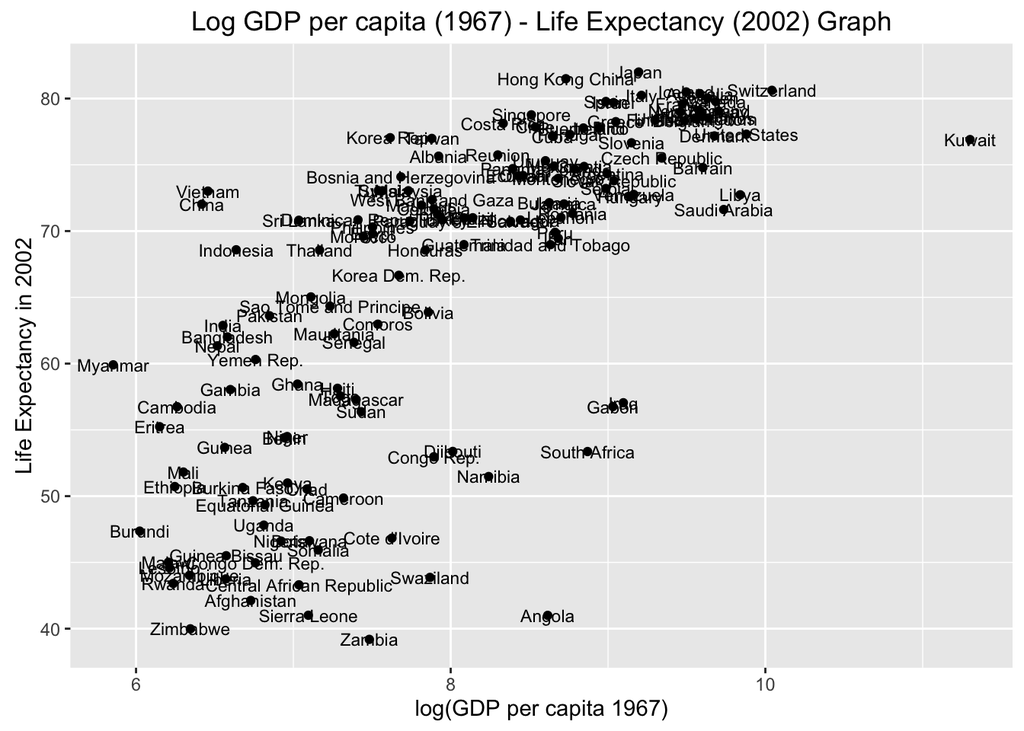

```r
ggplot(data=yr1967GDPyr2002LifeExp, aes(x=yr1967GDPyr2002LifeExp$logGDP, y=yr1967GDPyr2002LifeExp$lifeExp)) +
  geom_point() +
  xlab("log(GDP per capita 1967)") +
  ylab("Life Expectancy in 2002") +
  ggtitle("Log GDP per capita (1967) - Life Expectancy (2002) Graph") +
  geom_text(aes(label=yr1967GDPyr2002LifeExp$country), size=3)
```

### 11. Graph a scatter plot with an x axis of (GDP per capita per continent in 1967)“, and a y axis of expectancy per continent in 1967”.

```r
lifeExp_bycontinents_byyear <- gapminder %>%
  group_by(continent,year) %>%
  summarize(mean_lifeExp=mean(lifeExp))
```

```r
yr1967ContiGdpPercap <- gdp_bycontinents_byyear %>%
  filter(year==1967)
yr1967ContiLifeExp <- lifeExp_bycontinents_byyear %>%
  filter(year==1967)
```

```r
yr1967ContiLogGdpPercap <- yr1967ContiGdpPercap %>%
  mutate(logGDP=log(mean_gdpPercap))
```

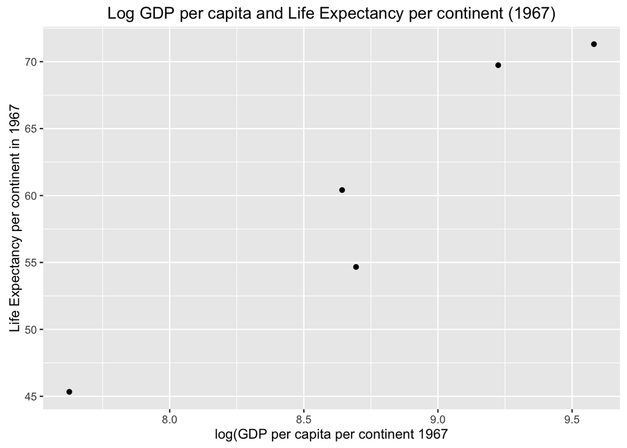

```r
yr1967GDPyr1967LifeExp <- merge(yr1967ContiLogGdpPercap, yr1967ContiLifeExp, by.x="continent", by.y="continent")
ggplot(data=yr1967GDPyr1967LifeExp, aes(x=yr1967GDPyr1967LifeExp$logGDP, y=yr1967GDPyr1967LifeExp$mean_lifeExp)) + geom_point() +
  xlab("log(GDP per capita per continent 1967") +
  ylab("Life Expectancy per continent in 1967") +
  ggtitle("Log GDP per capita and Life Expectancy per continent (1967)")
```

### 12. Graph (line plot) x: year, y: Log(GDP per capita per continent)

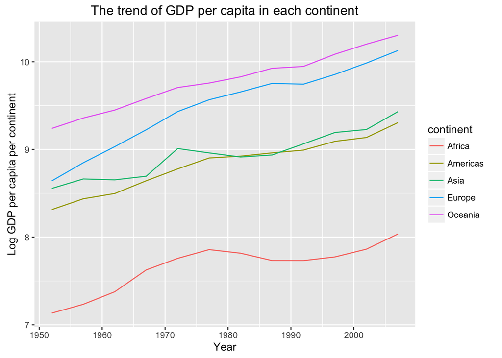

```r
LogGdp_bycontinents_byyear <- gdp_bycontinents_byyear %>%
  mutate(logGDP=log(mean_gdpPercap))
ggplot(data=LogGdp_bycontinents_byyear, aes(x=LogGdp_bycontinents_byyear$year, y=LogGdp_bycontinents_byyear$logGDP, color=continent)) +
  geom_line() +
  xlab("Year") +
  ylab("Log GDP per capita per continent") +
  ggtitle("The trend of GDP per capita in each continent")
```

- Below, we use **ggvis** instead of **ggplot2** to create a line graph of year by a log of GDP per continent.
- **ggvis** is under active development and doesn’t have all the features of ggplot2. For instance, there isn’ta plot title (ggtitle)
- Notice how we just use the `log()` function inside the `ggvis` function instead of using `mutate()` – we could also do this transformation on the fly in ggplot2 as well. The choice of transforming in the graphing function or creating a new variable in the data frame depends on if you need that variable to persist for longer than a plot. If not, do the tranformation on the fly in the graph.

```r
# going from gapminder to
gapminder %>%
  group_by(continent,year) %>%
  summarize(mean_gdpPercap=mean(gdpPercap)) %>%
  ggvis(~year, ~log(mean_gdpPercap), stroke = ~continent) %>%
  layer_lines() %>%
  add_axis("x", title = "Year", format='####') %>%
  add_axis("y", title = "Log GDP per capita per continent")
```

## 1.2 Tidyr - Wide to long and back again

### 1. Load the revenue.csv le into your R project.

```r
revenue <- read.csv('https://raw.githubusercontent.com/ucsdlib/win2016-gps-intro-R/gh-pages/data/revenue.csv', header = T)
```

### 2. By using gather(), `gather’ the quarter revenues into Quarter and Revenue.

```r
longRev <- revenue %>% gather(Quarter, Revenue, Qtr.1:Qtr.4)
head(longRev)
```

```
##   Group Year Quarter Revenue
## 1     1 2006   Qtr.1      15
## 2     1 2007   Qtr.1      12
## 3     1 2008   Qtr.1      22
## 4     1 2009   Qtr.1      10
## 5     2 2006   Qtr.1      12
## 6     2 2007   Qtr.1      16
```

### 3. By using separate(), `separate’ each of the Quarter strings into Time Interval and Interval ID

```r
separateRev <- longRev %>% separate(Quarter, c("Time_Interval", "Interval_ID"))
head(separateRev)
```

```
##   Group Year Time_Interval Interval_ID Revenue
## 1     1 2006           Qtr           1      15
## 2     1 2007           Qtr           1      12
## 3     1 2008           Qtr           1      22
## 4     1 2009           Qtr           1      10
## 5     2 2006           Qtr           1      12
## 6     2 2007           Qtr           1      16
```

### 4. By using unite(), re-unite the Time Interval and Interval ID and re-create the original Quarter variable.

```r
uniteRev <- separateRev %>% unite(Quarter, Time_Interval, Interval_ID, sep=".")
head(uniteRev)
```

```
##   Group Year Quarter Revenue
## 1     1 2006   Qtr.1      15
## 2     1 2007   Qtr.1      12
## 3     1 2008   Qtr.1      22
## 4     1 2009   Qtr.1      10
## 5     2 2006   Qtr.1      12
## 6     2 2007   Qtr.1      16
```

### 5. By using spread(), restore the original structure of the dataframe.

```r
wideRev <- uniteRev %>% spread(Quarter, Revenue)
head(wideRev)
```

```
##   Group Year Qtr.1 Qtr.2 Qtr.3 Qtr.4
## 1     1 2006    15    16    19    17
## 2     1 2007    12    13    27    23
## 3     1 2008    22    22    24    20
## 4     1 2009    10    14    20    16
## 5     2 2006    12    13    25    18
## 6     2 2007    16    14    21    19
```